# Flexible Damage Functions

Author

James Rising, Sebastian Cadavid Sanchez, Climate Impact Lab

Published

April 30, 2026

## 0.1 Agriculture: Corn Country

Flexible damage function parameters at the Country level.

**Change in corn yields (log change in yields) under full adaptation**

**Outcome units:** `physical` — log change in corn yield (population-weighted to country)

$$D_{it} = (\alpha_i T_t + \beta_i T_t^2) \cdot Y_{it}^{\gamma}$$

where $\gamma$ is the income elasticity (fitted globally), $\alpha_i$ is the linear coefficient, and $\beta_i$ is the quadratic coefficient.

# 1 Global Estimation

## 1.1 Income Elasticity Estimation

The income elasticity $\gamma$ is estimated using a fixed-effects regression:

$$y_{it} = \gamma \cdot \log(Y_{it}) + \mu_{g(i,T)} + \nu_t + \varepsilon_{it}$$

where $\mu_{g(i,T)}$ are region-by-temperature-bin fixed effects and $\nu_t$ are year fixed effects.

Table 1: Income Elasticity (Gamma) Estimation Results

| Statistic | Value |
| --- | --- |
| Income elasticity ($\gamma$) | 0.3129 |
| Standard error | 8.82e-03 |
| 95% CI | [0.2956, 0.3302] |
| R-squared | 0.5356 |
| Observations | 3,681,476 |
| Regions | 177 |
| Gamma quantiles | 19 |

# 2 Parameter Distributions

## 2.1 8-Panel Summary

Row 1: gamma, alpha, beta, rsqr1. Row 2: rho, zeta, eta, rsqr2.

```
Using median gamma: 0.312898, 177 rows (of 3,363 total)
```

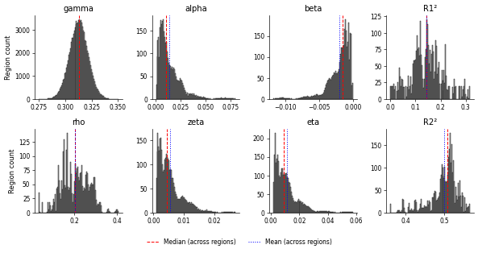

Figure 1: Distribution of Regional Parameters

## 2.2 Projection Equation and Parameter Definitions

The estimated parameters are used to project damages via Monte Carlo sampling:

$$D_{it}^k = (\hat{\alpha}_{ik} T_t + \hat{\beta}_{ik} T_t^2) Y_{it}^{\hat{\gamma}_k} + \hat{\theta}_{ik} T_t Y_{it}^{\hat{\gamma}_k} + \hat{\phi}_{it}^k$$

where $k$ indexes the Monte Carlo draw. The parameters in each row of the output CSV control distinct components of this equation:

- **gamma**: income elasticity $\hat{\gamma}_k$, one of 19 quantile values drawn from $N(\hat{\gamma}, SE(\hat{\gamma}))$
- **alpha, beta**: linear and quadratic temperature coefficients; $\hat{\alpha}_{ik}$ and $\hat{\beta}_{ik}$ are drawn from the joint normal defined by the VCV below
- **sigma11, sigma12, sigma22**: variance-covariance matrix of $(\alpha, \beta)$, used for joint uncertainty sampling
- **rho**: correlation between regional and global polynomial residuals $\rho_i$, used to maintain spatial covariance across regions in Monte Carlo draws
- **zeta**: temperature-dependent error scale $\zeta_{ik}$; the run-specific error term $\hat{\theta}_{ik}$ is drawn from $N(0, \zeta_{ik})$
- **eta**: residual noise standard deviation $\eta_{ik}$; the annual noise $\hat{\phi}_{it}^k$ is drawn from $N(0, \eta_{ik})$
- **rsqr1, rsqr2**: polynomial fit quality and error model fit, respectively

## 2.3 Summary Statistics

Table 2: Regional Parameter Summary

| Parameter | Mean | Median | Std | Min | Max | N |
| --- | --- | --- | --- | --- | --- | --- |
| alpha | 0.01384 | 0.01068 | 0.0113 | 0.0008007 | 0.07292 | 177 |
| beta | -0.002007 | -0.001532 | 0.00171 | -0.01073 | 0 | 177 |
| rho | 0.2027 | 0.204 | 0.065 | 0.03324 | 0.3986 | 177 |
| zeta | 0.005453 | 0.004442 | 0.003965 | 0.0009819 | 0.02488 | 177 |
| eta | 0.01101 | 0.008922 | 0.008432 | 0.001874 | 0.05311 | 177 |
| rsqr1 | 0.1441 | 0.1439 | 0.06652 | 0.0001161 | 0.316 | 177 |
| rsqr2 | 0.4995 | 0.5085 | 0.03781 | 0.3618 | 0.5669 | 177 |

# 3 Spaghetti Curves

Regional damage function curves showing D(T) = αT + βT² for sampled regions.

[interactive chart not shown]

Figure 2: Regional Damage Functions

# 4 Zero Crossings

The zero crossing (extremum) of the parabola occurs at $T^* = -\alpha / (2\beta)$.

Table 3: Zero Crossing Statistics

| Category | Count | Percentage |
| --- | --- | --- |
| β = 0 (no crossing) | 1 | 0.6% |
| T > 20°C (beyond graph) | 0 | 0.0% |
| T < 0°C (negative crossing) | 0 | 0.0% |
| Valid crossings (0-20°C) | 176 | 99.4% |

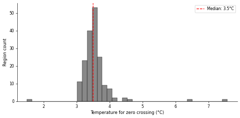

Figure 3: Distribution of Zero Crossing Temperatures

# 5 Slope Analysis

Maximum slope between 0 and 10°C: $\frac{dM}{dT} = \alpha + 2\beta T$

The maximum occurs at either T=0 or T=10 (endpoints of interval).

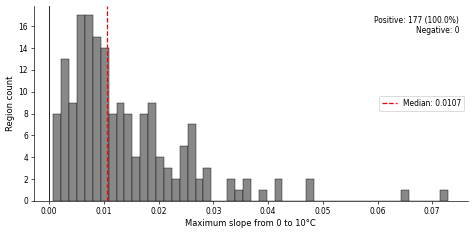

Figure 4: Distribution of Maximum Slopes (0-10°C)

*Convexity analysis omitted (beta constraint active).*

# 6 R-squared Analysis

## 6.1 Polynomial Fit Quality (rsqr1)

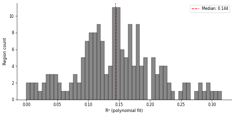

Figure 5: Regional Fit Quality (R-squared)

## 6.2 Error Model R-squared (rsqr2) Quantiles

Table 4: rsqr2 Quantiles

| 0% (Min) | 25% | 50% (Median) | 75% | 100% (Max) |
| --- | --- | --- | --- | --- |
| 0.3618 | 0.4863 | 0.5085 | 0.5216 | 0.5669 |

# 7 Modelled Variance

Modelled variance statistic: $1 - \frac{\sum_i \eta_i^2}{\sum_i D_i^2}$

Table 5: Modelled Variance Statistics

| Statistic | Value |
| --- | --- |
| Modelled variance | 0.7854 |
| Sum(η²) | 0.0340 |
| Sum(D²) at T=3.0°C | 0.1583 |
| N regions | 177 |

# 8 Best- and Worst-Fitting Regions

The 3 worst- and 3 best-fitting regions by R-squared, with raw simulation data overlaid on the fitted polynomial curve. **Red rows = worst fits**, **green rows = best fits**.

Table 6: Best- and worst-fitting regions

Top 3 best fit (R²) Top 3 worst fit (R²)

| Region | α | β | η | R² |
| --- | --- | --- | --- | --- |
| AFG | 0.0194 | -0.00269 | 0.00871 | 0.316 |
| PSE | 0.0241 | -0.00356 | 0.0102 | 0.309 |
| JOR | 0.0183 | -0.00267 | 0.00798 | 0.298 |
| BGD | 0.0073 | -0.00104 | 0.0359 | 0.00475 |
| MAC | 0.00236 | -3.10e-4 | 0.0105 | 0.00707 |
| BTN | 0.00996 | -0.00162 | 0.0234 | 0.0147 |

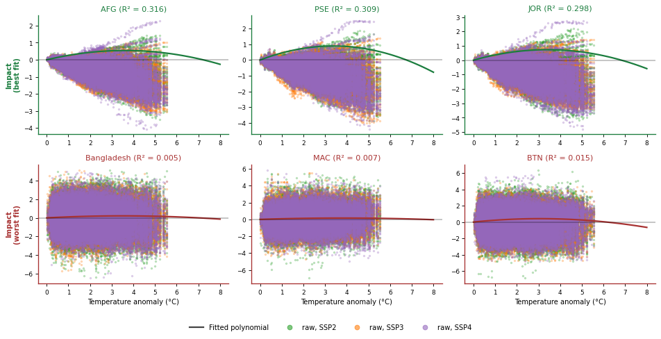

# 9 Regional Parameter Maps

Maps of key parameters at the **country** level. Red = negative (damage increases with T), Blue = positive.

## 9.1 Alpha (Linear Coefficient)

Alpha ($\alpha$) represents the linear sensitivity to temperature. Regions with negative alpha experience damage that increases with the first degree of warming.

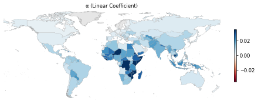

Figure 7: α (linear coefficient)

## 9.2 Beta (Quadratic Coefficient)

Beta ($\beta$) represents the curvature of the damage function.

The concavity ($\beta \leq 0$) constraint is enforced for this sector, meaning optimal temperature exists, damages accelerate beyond it.

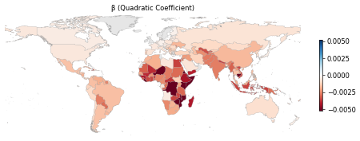

Figure 8: β (quadratic coefficient)

## 9.3 R-squared (Fit Quality)

$R^2$ measures the polynomial fit quality. Higher values indicate that the quadratic form captures more of the variance in the data.

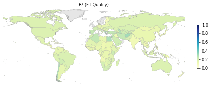

Figure 9: R² (stage 1 fit quality)

# 10 F2: Flex vs Raw Comparison

Comparison of flexible damage function predictions against raw simulation means.

For each scenario (RCP × SSP × Model), we compute at the final year:

- **Flex predicted**: $(\alpha \cdot T + \beta \cdot T^2) \cdot Y^\gamma$
- **Raw actual**: The outcome variable (y) from the source data

**Year 2098**: 1,457,280 rows

**rcp45**

**SSP2**

**high**

**Correlation:** -0.0360 | **RMSE:** 0.847926 | **Sign agreement:** 41.2%

[interactive chart not shown]

Top 5 best predicted Top 5 worst predicted

Year 2098 · T<sub>mean</sub> across these regions: 1.94°C

| Region | Raw | Flex | Residual |
| --- | --- | --- | --- |
| KOR | 0.303 | 0.303 | -1.81e-4 |
| EST | 0.156 | 0.163 | 0.00703 |
| NZL | 0.164 | 0.146 | -0.0175 |
| DNK | 0.144 | 0.126 | -0.0183 |
| JPN | 0.208 | 0.175 | -0.033 |
| ZWE | -0.124 | 2.43 | 2.55 |
| EGY | -0.905 | 1.17 | 2.08 |
| MWI | -0.0823 | 1.84 | 1.92 |
| LBR | 0.0495 | 1.84 | 1.79 |
| DJI | -0.214 | 1.55 | 1.76 |

**low**

**Correlation:** -0.1549 | **RMSE:** 0.740774 | **Sign agreement:** 39.0%

[interactive chart not shown]

Top 5 best predicted Top 5 worst predicted

Year 2098 · T<sub>mean</sub> across these regions: 1.94°C

| Region | Raw | Flex | Residual |
| --- | --- | --- | --- |
| KOR | 0.231 | 0.229 | -0.00234 |
| DNK | 0.118 | 0.115 | -0.00266 |
| LUX | 0.131 | 0.138 | 0.00693 |
| NZL | 0.159 | 0.137 | -0.0217 |
| NLD | 0.14 | 0.171 | 0.0311 |
| SOM | -0.176 | 1.9 | 2.08 |
| EGY | -0.848 | 0.91 | 1.76 |
| PSE | -0.489 | 1.15 | 1.64 |
| DJI | -0.635 | 0.98 | 1.62 |
| ZWE | -0.129 | 1.48 | 1.61 |

**SSP3**

**high**

**Correlation:** -0.1186 | **RMSE:** 0.665112 | **Sign agreement:** 40.7%

[interactive chart not shown]

Top 5 best predicted Top 5 worst predicted

Year 2098 · T<sub>mean</sub> across these regions: 1.94°C

| Region | Raw | Flex | Residual |
| --- | --- | --- | --- |
| DNK | 0.13 | 0.114 | -0.0152 |
| EST | 0.13 | 0.147 | 0.0178 |
| KOR | 0.299 | 0.278 | -0.0217 |
| NZL | 0.162 | 0.132 | -0.0293 |
| NLD | 0.11 | 0.145 | 0.0356 |
| ZWE | -0.138 | 1.7 | 1.84 |
| EGY | -0.894 | 0.907 | 1.8 |
| DJI | -0.317 | 1.15 | 1.47 |
| TKM | -0.799 | 0.657 | 1.46 |
| JOR | -0.713 | 0.705 | 1.42 |

**low**

**Correlation:** -0.3032 | **RMSE:** 0.612079 | **Sign agreement:** 32.2%

[interactive chart not shown]

Top 5 best predicted Top 5 worst predicted

Year 2098 · T<sub>mean</sub> across these regions: 1.94°C

| Region | Raw | Flex | Residual |
| --- | --- | --- | --- |
| DNK | 0.119 | 0.114 | -0.00492 |
| LUX | 0.137 | 0.13 | -0.00721 |
| MAC | 0.111 | 0.12 | 0.00897 |
| NLD | 0.139 | 0.164 | 0.0246 |
| NZL | 0.159 | 0.132 | -0.0264 |
| EGY | -0.804 | 0.715 | 1.52 |
| UZB | -0.532 | 0.89 | 1.42 |
| TKM | -0.745 | 0.649 | 1.39 |
| PSE | -0.514 | 0.845 | 1.36 |
| IRQ | -0.868 | 0.491 | 1.36 |

**SSP4**

**high**

**Correlation:** -0.2468 | **RMSE:** 0.683633 | **Sign agreement:** 42.9%

[interactive chart not shown]

Top 5 best predicted Top 5 worst predicted

Year 2098 · T<sub>mean</sub> across these regions: 1.94°C

| Region | Raw | Flex | Residual |
| --- | --- | --- | --- |
| EST | 0.169 | 0.166 | -0.00242 |
| NLD | 0.146 | 0.165 | 0.0182 |
| AUT | 0.103 | 0.125 | 0.0224 |
| LUX | 0.0769 | 0.102 | 0.0256 |
| NZL | 0.179 | 0.153 | -0.026 |
| EGY | -0.83 | 1.15 | 1.98 |
| ZWE | -0.248 | 1.58 | 1.83 |
| JOR | -0.7 | 0.865 | 1.57 |
| TKM | -0.789 | 0.734 | 1.52 |
| UZB | -0.58 | 0.93 | 1.51 |

**low**

**Correlation:** -0.2210 | **RMSE:** 0.641877 | **Sign agreement:** 35.0%

[interactive chart not shown]

Top 5 best predicted Top 5 worst predicted

Year 2098 · T<sub>mean</sub> across these regions: 1.94°C

| Region | Raw | Flex | Residual |
| --- | --- | --- | --- |
| BRN | 0.0696 | 0.0653 | -0.00431 |
| NLD | 0.157 | 0.171 | 0.0137 |
| DNK | 0.13 | 0.114 | -0.0152 |
| LUX | 0.157 | 0.136 | -0.0206 |
| EST | 0.0955 | 0.131 | 0.0356 |
| EGY | -0.85 | 0.791 | 1.64 |
| SOM | -0.246 | 1.34 | 1.59 |
| DJI | -0.756 | 0.744 | 1.5 |
| UZB | -0.563 | 0.848 | 1.41 |
| IRQ | -0.886 | 0.498 | 1.38 |

**rcp85**

**SSP2**

**high**

**Correlation:** 0.0701 | **RMSE:** 1.213296 | **Sign agreement:** 35.6%

[interactive chart not shown]

Top 5 best predicted Top 5 worst predicted

Year 2098 · T<sub>mean</sub> across these regions: 4.17°C

| Region | Raw | Flex | Residual |
| --- | --- | --- | --- |
| FIN | 0.133 | 0.134 | 0.00145 |
| TWN | 0.335 | 0.33 | -0.00451 |
| DNK | 0.165 | 0.171 | 0.00629 |
| EST | 0.16 | 0.192 | 0.0326 |
| PRK | 0.393 | 0.427 | 0.0338 |
| EGY | -1.94 | 1.38 | 3.32 |
| ZWE | -0.259 | 2.62 | 2.88 |
| JOR | -1.56 | 1.02 | 2.58 |
| PSE | -1.19 | 1.33 | 2.52 |
| DJI | -0.659 | 1.81 | 2.47 |

**low**

**Correlation:** -0.0668 | **RMSE:** 1.124352 | **Sign agreement:** 31.6%

[interactive chart not shown]

Top 5 best predicted Top 5 worst predicted

Year 2098 · T<sub>mean</sub> across these regions: 4.17°C

| Region | Raw | Flex | Residual |
| --- | --- | --- | --- |
| FIN | 0.123 | 0.131 | 0.00773 |
| MAC | 0.136 | 0.168 | 0.032 |
| PRK | 0.341 | 0.374 | 0.0331 |
| DNK | 0.121 | 0.157 | 0.0361 |
| TWN | 0.261 | 0.33 | 0.0696 |
| EGY | -1.77 | 1.07 | 2.84 |
| SOM | -0.471 | 2.21 | 2.68 |
| PSE | -1.18 | 1.33 | 2.51 |
| IRQ | -1.7 | 0.74 | 2.44 |
| DJI | -1.22 | 1.15 | 2.36 |

**SSP3**

**high**

**Correlation:** -0.0439 | **RMSE:** 1.104087 | **Sign agreement:** 29.9%

[interactive chart not shown]

Top 5 best predicted Top 5 worst predicted

Year 2098 · T<sub>mean</sub> across these regions: 4.17°C

| Region | Raw | Flex | Residual |
| --- | --- | --- | --- |
| PRK | 0.326 | 0.34 | 0.0138 |
| TWN | 0.258 | 0.297 | 0.0392 |
| FIN | 0.0828 | 0.123 | 0.0398 |
| DNK | 0.115 | 0.155 | 0.0401 |
| MAC | 0.204 | 0.156 | -0.0486 |
| EGY | -1.92 | 1.07 | 2.99 |
| JOR | -1.67 | 0.825 | 2.5 |
| PSE | -1.4 | 0.977 | 2.37 |
| TKM | -1.65 | 0.694 | 2.34 |
| SYR | -1.61 | 0.692 | 2.31 |

**low**

**Correlation:** -0.2374 | **RMSE:** 1.016748 | **Sign agreement:** 26.0%

[interactive chart not shown]

Top 5 best predicted Top 5 worst predicted

Year 2098 · T<sub>mean</sub> across these regions: 4.17°C

| Region | Raw | Flex | Residual |
| --- | --- | --- | --- |
| PRK | 0.301 | 0.302 | 0.00124 |
| FIN | 0.0939 | 0.122 | 0.0279 |
| DNK | 0.125 | 0.155 | 0.0295 |
| TWN | 0.253 | 0.297 | 0.0446 |
| MAC | 0.216 | 0.156 | -0.0604 |
| EGY | -1.7 | 0.842 | 2.54 |
| PSE | -1.3 | 0.977 | 2.27 |
| UZB | -1.32 | 0.937 | 2.26 |
| TKM | -1.57 | 0.686 | 2.26 |
| IRQ | -1.68 | 0.558 | 2.24 |

**SSP4**

**high**

**Correlation:** -0.1920 | **RMSE:** 1.119071 | **Sign agreement:** 29.4%

[interactive chart not shown]

Top 5 best predicted Top 5 worst predicted

Year 2098 · T<sub>mean</sub> across these regions: 4.17°C

| Region | Raw | Flex | Residual |
| --- | --- | --- | --- |
| FIN | 0.136 | 0.139 | 0.00326 |
| DNK | 0.18 | 0.177 | -0.00366 |
| BRN | 0.232 | 0.219 | -0.0132 |
| TWN | 0.317 | 0.343 | 0.0258 |
| MAC | 0.192 | 0.166 | -0.0259 |
| EGY | -1.92 | 1.35 | 3.27 |
| JOR | -1.64 | 1.01 | 2.65 |
| TKM | -1.66 | 0.775 | 2.44 |
| IRQ | -1.79 | 0.622 | 2.41 |
| DZA | -1.56 | 0.835 | 2.4 |

**low**

**Correlation:** -0.1666 | **RMSE:** 1.088411 | **Sign agreement:** 23.7%

[interactive chart not shown]

Top 5 best predicted Top 5 worst predicted

Year 2098 · T<sub>mean</sub> across these regions: 4.17°C

| Region | Raw | Flex | Residual |
| --- | --- | --- | --- |
| FIN | 0.134 | 0.133 | -8.62e-4 |
| BRN | 0.167 | 0.14 | -0.0268 |
| PRK | 0.284 | 0.32 | 0.0369 |
| DNK | 0.115 | 0.156 | 0.041 |
| KOR | 0.376 | 0.284 | -0.0922 |
| EGY | -1.82 | 0.932 | 2.75 |
| JOR | -1.6 | 0.727 | 2.33 |
| IRQ | -1.73 | 0.567 | 2.3 |
| PSE | -1.38 | 0.9 | 2.28 |
| UZB | -1.38 | 0.892 | 2.27 |

## 10.1 Scenario Summary

Table 7: Fit statistics across all 12 scenarios

| RCP | SSP | Model | N | Corr | RMSE | Sign% |
| --- | --- | --- | --- | --- | --- | --- |
| rcp45 | SSP2 | high | 177 | -0.036 | 0.847926 | 41.2% |
| rcp45 | SSP2 | low | 177 | -0.1549 | 0.740774 | 39.0% |
| rcp45 | SSP3 | high | 177 | -0.1186 | 0.665112 | 40.7% |
| rcp45 | SSP3 | low | 177 | -0.3032 | 0.612079 | 32.2% |
| rcp45 | SSP4 | high | 177 | -0.2468 | 0.683633 | 42.9% |
| rcp45 | SSP4 | low | 177 | -0.221 | 0.641877 | 35.0% |
| rcp85 | SSP2 | high | 177 | 0.0701 | 1.2133 | 35.6% |
| rcp85 | SSP2 | low | 177 | -0.0668 | 1.12435 | 31.6% |
| rcp85 | SSP3 | high | 177 | -0.0439 | 1.10409 | 29.9% |
| rcp85 | SSP3 | low | 177 | -0.2374 | 1.01675 | 26.0% |
| rcp85 | SSP4 | high | 177 | -0.192 | 1.11907 | 29.4% |
| rcp85 | SSP4 | low | 177 | -0.1666 | 1.08841 | 23.7% |

# 11 Data Reference

## 11.1 File Locations

| Item | Path |
| --- | --- |
| Regional CSV | `/project/cil/gcp/flex_damage_funcs/parameters/agriculture__corn_country__regional_parameters.csv` |
| Global JSON | `/project/cil/gcp/flex_damage_funcs/parameters/agriculture__corn_country__global_results.json` |
| Metadata JSON | `/project/cil/gcp/flex_damage_funcs/parameters/agriculture__corn_country__metadata.json` |

## 11.2 Column Definitions

| Column | Description |
| --- | --- |
| `region` | Region identifier (hierarchical code, first 3 chars = country ISO3) |
| `gamma` | Income elasticity quantile value |
| `alpha` | Linear temperature coefficient |
| `beta` | Quadratic temperature coefficient |
| `sigma11` | Var(alpha) |
| `sigma12` | Cov(alpha, beta) |
| `sigma22` | Var(beta) |
| `rho` | Correlation with global residual process |
| `zeta` | Temperature-dependent heteroskedasticity |
| `eta` | Residual standard deviation |
| `rsqr1` | R-squared of polynomial fit |
| `rsqr2` | R-squared of error model |

*Report generated with FlexDamage v1.0.0*